# Latihan 3 MPDW

Lutfi Syahreza Lubis

2023-09-14

# Data Preparation

## Packages

```r
library(dLagM)
library(dynlm)
library(MLmetrics)
library(lmtest)
library(car)
```

## Importing Data

```r
data_winee <- rio::import("https://raw.githubusercontent.com/lutfi-reza/mpdw-lutfi-reza/main/data/data_wine.csv")

# membalik data
flip <- function(data){
  new <- data[rev(rownames(data)),]
  rownames(new) <- NULL
  new
}

# data yang akan dipakai
data_wine <- flip(data_winee)
```

```r
t <- data_wine$Tahun
Xt <- data_wine$Panen
Yt <- data_wine$Harga

data_lag1 <- cbind(t, Xt, Yt)
data_lag <- as.data.frame(data_lag1)
```

## Dividing dataset into training and testing data

```r
train <- data_lag[1:33,]
test <- data_lag[34:41,]
```

## Time series data

```r
train.ts<-ts(train)
test.ts<-ts(test)
data_lag.ts<-ts(data_lag)
```

# Model Koyck

Model Koyck didasarkan pada asumsi bahwa semakin jauh jarak lag peubah independen dari periode sekarang maka semakin kecil pengaruh peubah lag terhadap peubah dependen.

Koyck mengusulkan suatu metode untuk menduga model dinamis distributed lag dengan mengasumsikan bahwa semua koefisien $\beta$ mempunyai tanda sama.

Model kyock merupakan jenis paling umum dari model infinite distributed lag dan juga dikenal sebagai geometric lag

$$y_t=a(1-\lambda)+\beta_0X_t+\beta_1Z_t+\lambda Y_{t-1}+V_t$$
dengan
$$V_t=u_t-\lambda
u_{t-1}$$

## Koyck Modelling

```r
#Koyck Model
model.koyck <- dLagM :: koyckDlm(x=train$Xt , y=train$Yt)
summary(model.koyck)
```

```
##
## Call:
## "Y ~ (Intercept) + Y.1 + X.t"
##
## Residuals:
##     Min      1Q  Median      3Q     Max
## -89.405 -34.849  -6.533  30.961 192.910
##
## Coefficients:
##              Estimate Std. Error t value Pr(>|t|)
## (Intercept) 45.191046  38.141931   1.185    0.246
## Y.1          0.926273   0.115437   8.024 7.54e-09 ***
## X.t          0.000454   0.004341   0.105    0.917
## ---
## Signif. codes:  0 '***' 0.001 '**' 0.01 '*' 0.05 '.' 0.1 ' ' 1
##
## Residual standard error: 63.36 on 29 degrees of freedom
## Multiple R-Squared: 0.8728,  Adjusted R-squared: 0.864
## Wald test: 99.47 on 2 and 29 DF,  p-value: 1.039e-13
##
## Diagnostic tests:
## NULL
##
##                             alpha         beta       phi
## Geometric coefficients:  612.9506 0.0004539983 0.9262729
```

$$\hat{Y_t}=45.191046+0.000454X_t+926273Y_{t-1}$$

```r
AIC(model.koyck)
```

```
## [1] 361.1827
```

```r
BIC(model.koyck)
```

```
## [1] 367.0457
```

## Koyck Forecasting

Berikut adalah hasil peramalan y untuk 8 periode kedepan menggunakan model koyck

```r
(fore.koyck <- forecast(model = model.koyck, x=test$Xt, h=8))
```

```
## $forecasts
## [1] 692.7408 692.5785 692.7460 693.4459 694.2304 694.9570 697.5823 700.0594
##
## $call
## forecast.koyckDlm(model = model.koyck, x = test$Xt, h = 8)
##
## attr(,"class")
## [1] "forecast.koyckDlm" "dLagM"
```

## Koyck Model Accuracy

```r
#mape data testing
mape.koyck <- MAPE(fore.koyck$forecasts, test$Yt)

#akurasi data training
mape_train <- dLagM::GoF(model.koyck)["MAPE"]

c("MAPE_testing" = mape.koyck, "MAPE_training" = mape_train)
```

```
## $MAPE_testing
## [1] 0.09896215
##
## $MAPE_training.MAPE
## [1] 0.1015234
```

# Regression with Distributed Lag

Fungsi `dlm()` akan menerapkan model lag terdistribusi dengan satu atau lebih prediktor. Nilai `x` dan `y` tidak perlu sebagai objek *time series* (`ts`). $q$ adalah integer yang mewakili panjang *lag* yang terbatas.

## DLM Modelling with Optimum Lag

```r
#penentuan lag optimum
lagop <- finiteDLMauto(formula=Yt ~ Xt,
              data = data.frame(train),model.type = "dlm",error.type = "AIC");lagop
```

```
##    q - k    MASE      AIC      BIC   GMRAE   MBRAE R.Adj.Sq   Ljung-Box
## 10    10 1.15734 289.2287 303.9901 0.94523 1.23846  0.23578 0.007189073
```

## Distributed Lag Modelling

```r
model.dlm = dLagM::dlm(x = train$Xt,y = train$Yt , q = 10)
summary(model.dlm)
```

```
##
## Call:
## lm(formula = model.formula, data = design)
##
## Residuals:
##     Min      1Q  Median      3Q     Max
## -112.64  -45.91  -20.89   31.62  178.06
##
## Coefficients:
##               Estimate Std. Error t value Pr(>|t|)
## (Intercept) 407.027953  54.209850   7.508 1.19e-05 ***
## x.t           0.030922   0.030804   1.004    0.337
## x.1           0.055601   0.047573   1.169    0.267
## x.2          -0.071397   0.045821  -1.558    0.147
## x.3           0.027366   0.050670   0.540    0.600
## x.4           0.008325   0.048735   0.171    0.867
## x.5          -0.003151   0.048298  -0.065    0.949
## x.6          -0.089931   0.068041  -1.322    0.213
## x.7          -0.001039   0.057965  -0.018    0.986
## x.8           0.106580   0.087544   1.217    0.249
## x.9          -0.008727   0.077248  -0.113    0.912
## x.10         -0.050275   0.073634  -0.683    0.509
## ---
## Signif. codes:  0 '***' 0.001 '**' 0.01 '*' 0.05 '.' 0.1 ' ' 1
##
## Residual standard error: 106.9 on 11 degrees of freedom
## Multiple R-squared:  0.6179, Adjusted R-squared:  0.2358
## F-statistic: 1.617 on 11 and 11 DF,  p-value: 0.219
##
## AIC and BIC values for the model:
##        AIC      BIC
## 1 289.2287 303.9901
```

Dari hasil diatas, didapat bahwa $P-value$ dari intercept $<0.05$, namun $P-value$ dari $x_{t-1}$ dan $x_1$ hingga $x_{10}$ $>0.05$. Hal ini menunjukkan bahwa intercept berpengaruh signifikan terhadap $y$, namun tidak untuk $x_{t-1}$ dan $x_1$ hingga $x_{10}$. Adapun model keseluruhan yang terbentuk adalah sebagai berikut

$$\hat{Y_t}=407.027953+0.030922X_t+0.055601X_{t-1}+-0.071397X_{t-2}+0.027366X_{t-3}+0.008325X_{t-4}-0.003151X_{t-5}-0.089931X_{t-6}-0.001039X_{t-7}+0.106580X_{t-8}-0.008727X_{t-9}-0.050275X_{t-10}$$
Hal ini berarti harga wine tidak dipengaruhi oleh jumlah panen anggur pada 10 hari sebelumnya. Model ini cukup baik dengan nilai R-Squared 61.79%.

```r
AIC(model.dlm)
```

```
## [1] 289.2287
```

```r
BIC(model.dlm)
```

```
## [1] 303.9901
```

## DLM Forecasting

Berikut adalah hasil peramalan y untuk 8 periode kedepan menggunakan model DLM

```r
#ramalan
(fore.dlm <- forecast(model = model.dlm, x=test$Xt, h=8))
```

```
## $forecasts
## [1] 230.0576 448.8461 544.1012 740.6476 747.4584 467.1311 566.4194 965.6556
##
## $call
## forecast.dlm(model = model.dlm, x = test$Xt, h = 8)
##
## attr(,"class")
## [1] "forecast.dlm" "dLagM"
```

#DLM Accuracy

```r
#mape data testing
mape.dlm <- MAPE(fore.dlm$forecasts, test$Yt)

#akurasi data training
mape_train <- dLagM::GoF(model.dlm)["MAPE"]

c("MAPE_testing" = mape.dlm, "MAPE_training" = mape_train)
```

```
## $MAPE_testing
## [1] 0.3320707
##
## $MAPE_training.MAPE
## [1] 0.1050982
```

# Autoregressive / Dynamic Regression Model

Peubah dependen dipengaruhi oleh peubah independen pada waktu sekarang, serta dipengaruhi juga oleh peubah dependen itu sendiri pada satu waktu yang lalu maka model tersebut disebut *autoregressive* (Gujarati 2004)

## ARDLM Modelling

Dengan $p$ adalah integer yang mewakili panjang *lag* yang terbatas dan $q$ adalah integer yang merepresentasikan ordo dari proses *autoregressive*.

```r
#optimum p & q
pqop <- ardlBoundOrders(data = data.frame(data_lag),ic = "AIC", formula = Yt ~ Xt )
c(p=pqop$p$Xt, q=pqop$q)
```

```
##  p  q
##  5 15
```

```r
min_p=c()
for(i in 1:15){
  min_p[i]=min(pqop$Stat.table[[i]])
}
q_opt=which(min_p==min(min_p, na.rm = TRUE))
p_opt=which(pqop$Stat.table[[q_opt]] ==
              min(pqop$Stat.table[[q_opt]], na.rm = TRUE))
data.frame("q_optimum" = q_opt, "p_optimum" = p_opt,
           "AIC"=pqop$min.Stat)
```

```
##   q_optimum p_optimum      AIC
## 1         4        15 142.8746
```

Berdasarkan penentuan nilai p dan q optimum diperoleh lagi optimum untuk peubah Xt atau panen adalah 5 hari sebelumnya dan lag optimum untuk peubah Yt atau harga wine adalah 15 hari sebelumnya.

```r
#ARDL MODEL
model.ardl = ardlDlm(x = train$Xt, y = train$Yt, p = 5 , q = 15)
summary(model.ardl)
```

```
##
## Time series regression with "ts" data:
## Start = 16, End = 33
##
## Call:
## dynlm(formula = as.formula(model.text), data = data, start = 1)
##
## Residuals:
## ALL 18 residuals are 0: no residual degrees of freedom!
##
## Coefficients: (4 not defined because of singularities)
##               Estimate Std. Error t value Pr(>|t|)
## (Intercept)  1.763e+03        NaN     NaN      NaN
## X.t          7.609e-01        NaN     NaN      NaN
## X.1          1.285e-01        NaN     NaN      NaN
## X.2         -3.571e-01        NaN     NaN      NaN
## X.3          8.734e-03        NaN     NaN      NaN
## X.4          4.392e-01        NaN     NaN      NaN
## X.5         -5.588e-01        NaN     NaN      NaN
## Y.1          1.004e+00        NaN     NaN      NaN
## Y.2         -6.317e+00        NaN     NaN      NaN
## Y.3         -5.000e+00        NaN     NaN      NaN
## Y.4          6.980e+00        NaN     NaN      NaN
## Y.5         -6.840e+00        NaN     NaN      NaN
## Y.6         -2.798e+00        NaN     NaN      NaN
## Y.7          6.449e+00        NaN     NaN      NaN
## Y.8         -1.840e+00        NaN     NaN      NaN
## Y.9          1.757e+00        NaN     NaN      NaN
## Y.10         3.588e+00        NaN     NaN      NaN
## Y.11        -8.231e+00        NaN     NaN      NaN
## Y.12                NA         NA      NA       NA
## Y.13                NA         NA      NA       NA
## Y.14                NA         NA      NA       NA
## Y.15                NA         NA      NA       NA
##
## Residual standard error: NaN on 0 degrees of freedom
## Multiple R-squared:      1,  Adjusted R-squared:    NaN
## F-statistic:   NaN on 17 and 0 DF,  p-value: NA
```

Melalui model ini diperoleh NaN pada error, t value, dan p-value. Oleh karena itu, nilai p dan q optimum ditelusuri lagi secara manual. Diperoleh p = 7 dan q = 11.

```r
model.ardl1 = ardlDlm(x = train$Xt, y = train$Yt, p = 7 , q = 11)
summary(model.ardl1)
```

```
##
## Time series regression with "ts" data:
## Start = 12, End = 33
##
## Call:
## dynlm(formula = as.formula(model.text), data = data, start = 1)
##
## Residuals:
##      12      13      14      15      16      17      18      19      20      21
## -14.598  14.516 -19.680  17.761 -21.064  46.600 -35.520  23.386  -8.128  -8.391
##      22      23      24      25      26      27      28      29      30      31
##   7.750  -5.058   3.409 -12.274  13.894  -1.336   1.102 -12.249  18.930 -23.751
##      32      33
##  25.535 -10.832
##
## Coefficients:
##               Estimate Std. Error t value Pr(>|t|)
## (Intercept) 472.730690 393.176530   1.202    0.352
## X.t           0.029976   0.037630   0.797    0.509
## X.1           0.023988   0.030408   0.789    0.513
## X.2          -0.079051   0.064856  -1.219    0.347
## X.3           0.047084   0.123824   0.380    0.740
## X.4          -0.020777   0.157995  -0.132    0.907
## X.5           0.009817   0.137507   0.071    0.950
## X.6          -0.007309   0.159382  -0.046    0.968
## X.7           0.053724   0.079034   0.680    0.567
## Y.1           0.967028   0.763985   1.266    0.333
## Y.2          -0.769490   1.377052  -0.559    0.633
## Y.3           0.151447   1.770378   0.086    0.940
## Y.4           0.476246   1.475951   0.323    0.778
## Y.5          -0.397647   0.963737  -0.413    0.720
## Y.6          -0.069543   0.690268  -0.101    0.929
## Y.7           0.191331   0.688398   0.278    0.807
## Y.8          -0.368244   0.694472  -0.530    0.649
## Y.9           0.047752   0.530823   0.090    0.937
## Y.10         -0.064929   0.766868  -0.085    0.940
## Y.11         -0.813993   0.924565  -0.880    0.472
##
## Residual standard error: 63.14 on 2 degrees of freedom
## Multiple R-squared:  0.9684, Adjusted R-squared:  0.6678
## F-statistic: 3.221 on 19 and 2 DF,  p-value: 0.2632
```

Melalui model ARDL tidak diperoleh peubah yang berpengaruh secara signifikan. Model ini cukup baik dengan nilai R-Square sebesar 96.84%.

```r
AIC(model.ardl1)
```

```
## [1] 234.0736
```

```r
BIC(model.ardl1)
```

```
## [1] 256.9855
```

## ARDL Forecasting

```r
(fore.ardl <- forecast(model = model.ardl1, x=test$Xt, h=8))
```

```
## $forecasts
## [1]  749.5517  972.3985 1048.5234 1177.0290 1142.8524 1084.8504 1192.5407
## [8] 1457.7017
##
## $call
## forecast.ardlDlm(model = model.ardl1, x = test$Xt, h = 8)
##
## attr(,"class")
## [1] "forecast.ardlDlm" "dLagM"
```

## ARDL Accuracy

```r
# mape akurasi testing
mape.ardl <- MAPE(fore.ardl$forecasts, test$Yt) #data testing

# mape akurasi data training
mape_train <- GoF(model.ardl1)["MAPE"]

c("MAPE_testing" = mape.ardl, "MAPE_training" = mape_train)
```

```
## $MAPE_testing
## [1] 0.4308798
##
## $MAPE_training.MAPE
## [1] 0.02699353
```

# Comparison of the Three Methods for Handling Autocorrelation

## Comparison according to mape value

```r
akurasi <- matrix(c(mape.koyck, mape.dlm, mape.ardl))
row.names(akurasi)<- c("Koyck","DLM","Autoregressive")
colnames(akurasi) <- c("MAPE")
akurasi
```

```
##                      MAPE
## Koyck          0.09896215
## DLM            0.33207071
## Autoregressive 0.43087981
```

Berdasarkan nilai MAPE, model paling optimum didapat pada Model Koyck karena memiliki nilai MAPE yang terkecil.

## Comparison plot of actual data with three autocorrelation handling methods

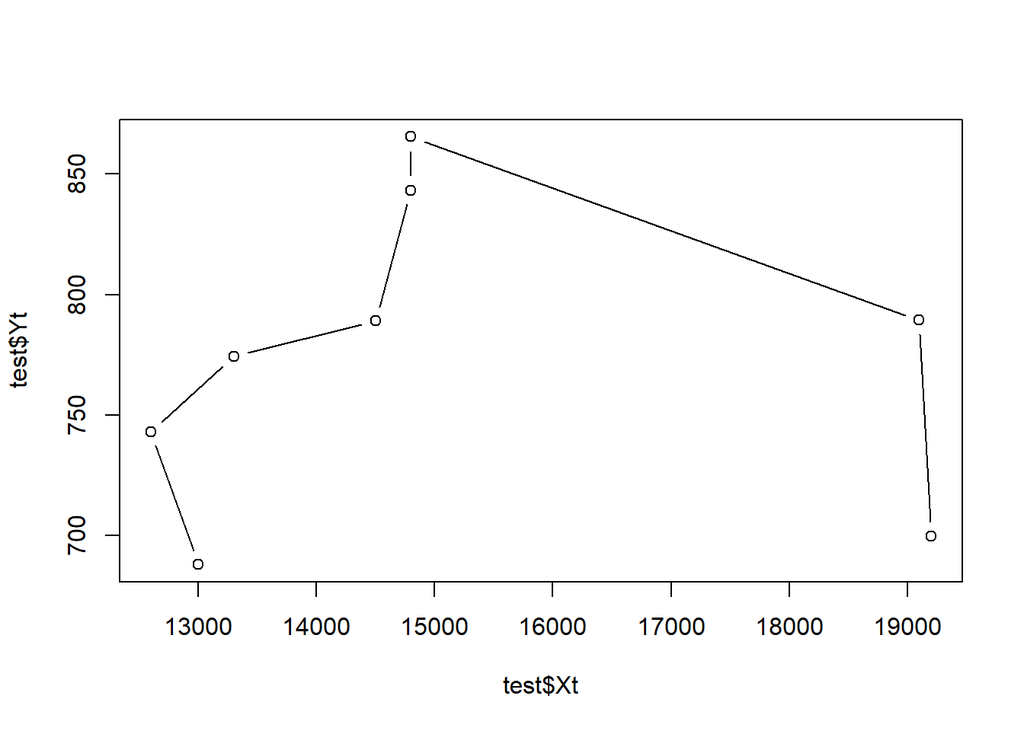

```r
par(mfrow=c(1,1))
plot(test$Xt, test$Yt, type="b", col="black")
```

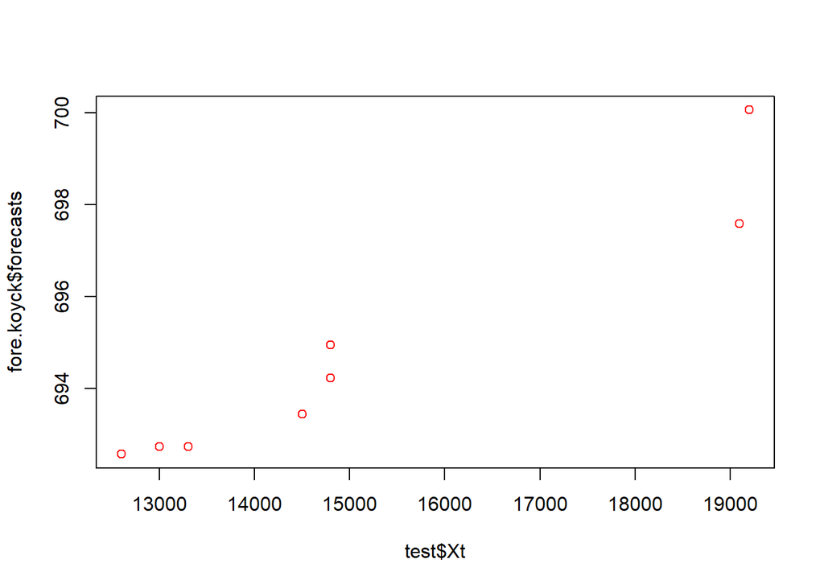

```r
plot(test$Xt, fore.koyck$forecasts,col="red")
```

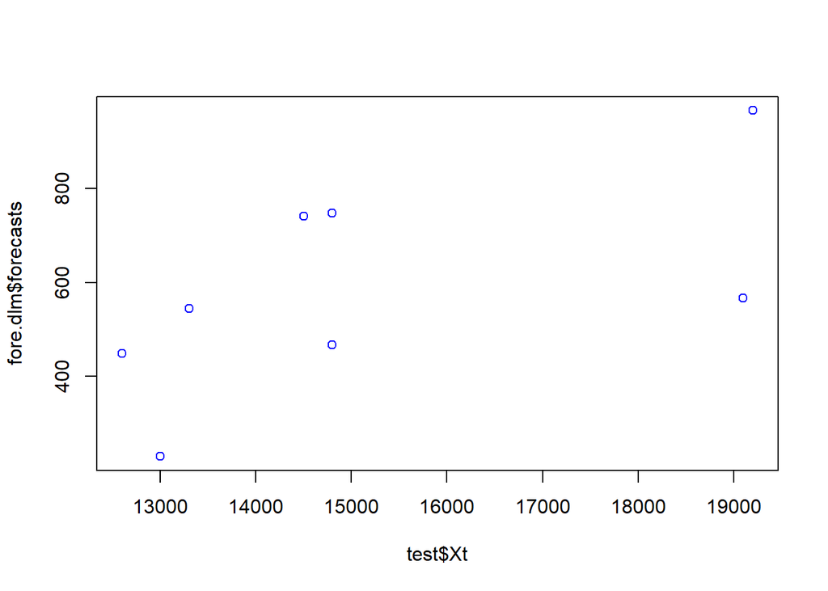

```r
plot(test$Xt, fore.dlm$forecasts,col="blue")
```

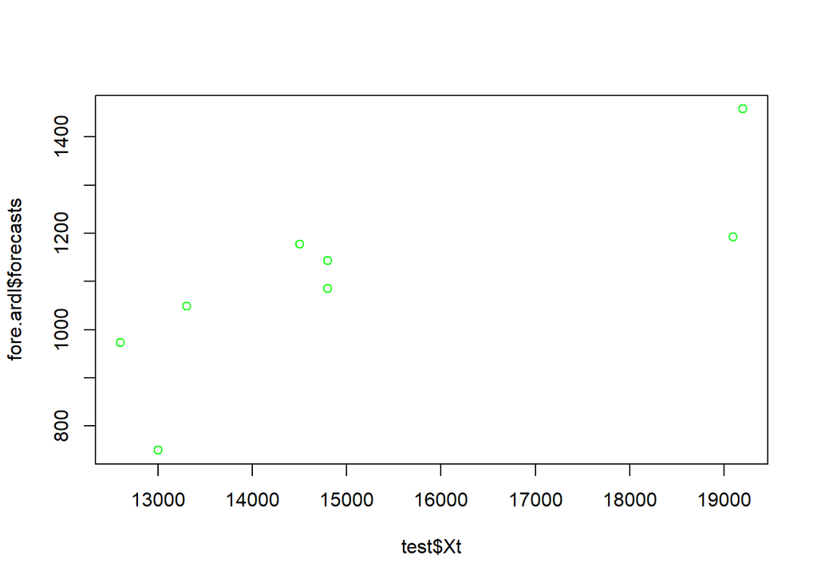

```r
plot(test$Xt, fore.ardl$forecasts,col="green")
```

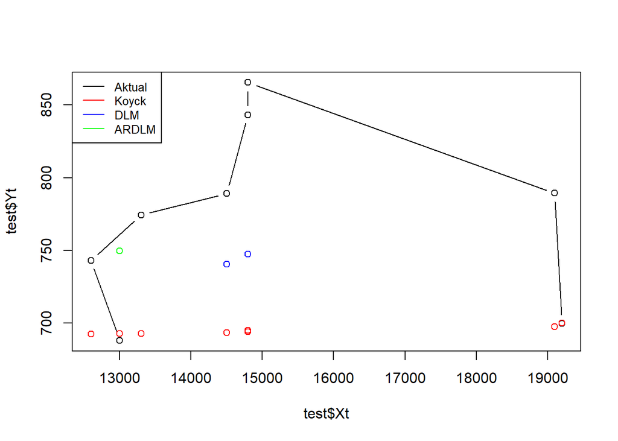

```r
plot(test$Xt, test$Yt, type="b", col="black")
points(test$Xt, fore.koyck$forecasts,col="red")
points(test$Xt, fore.dlm$forecasts,col="blue")
points(test$Xt, fore.ardl$forecasts,col="green")
legend("topleft",c("Aktual", "Koyck","DLM", "ARDLM"), lty=1, col=c("black","red","blue","green"), cex=0.8)
```

# Model Diagnostics

## Uji Non Autokorelasi

```r
#Breusch-Godfrey test
bgtest(model.koyck$model)
```

```
##
##  Breusch-Godfrey test for serial correlation of order up to 1
##
## data:  model.koyck$model
## LM test = 1.0118, df = 1, p-value = 0.3145
```

```r
#Durbin-Watson test
dwtest(model.koyck$model)
```

```
##
##  Durbin-Watson test
##
## data:  model.koyck$model
## DW = 1.6142, p-value = 0.06872
## alternative hypothesis: true autocorrelation is greater than 0
```

Berdasarkan uji Breusch-Godfrey dan uji Durbin-Watson dihasilkan nilai p-value > alpha 5% sehingga tidak terjadi autokorelasi. Autokorelasi pada model ini berhasil ditangani.

## Uji heterogenitas

```r
bptest(model.koyck$model)
```

```
##
##  studentized Breusch-Pagan test
##
## data:  model.koyck$model
## BP = 5.0284, df = 2, p-value = 0.08093
```

Berdasarkan uji Breusch-Pagan dihasilkan nilai p-value > alpha 5% sehingga tidak terjadi heteroskedastisitas pada model.

## Uji Normalitas

```r
ks.test(model.koyck$model$residuals, "pnorm")
```

```
##
##  Exact one-sample Kolmogorov-Smirnov test
##
## data:  model.koyck$model$residuals
## D = 0.5, p-value = 6.368e-08
## alternative hypothesis: two-sided
```

Berdasarkan uji uji Kolmogorov-Smirnov dihasilkan nilai p-value < alpha 5% sehingga residual data tidak menyebar normal.